# Weevils

John Godlee

18/07/2018

# Preamble

What version of R is being used?

```r
print(version)
```

```
##                _
## platform       x86_64-apple-darwin15.6.0
## arch           x86_64
## os             darwin15.6.0
## system         x86_64, darwin15.6.0
## status
## major          3
## minor          4.2
## year           2017
## month          09
## day            28
## svn rev        73368
## language       R
## version.string R version 3.4.2 (2017-09-28)
## nickname       Short Summer
```

```r
citation(package = "base", lib.loc = NULL, auto = NULL)
```

```
##
##
##   R Core Team (2017). R: A language and environment for
##   statistical computing. R Foundation for Statistical Computing,
##   Vienna, Austria. URL https://www.R-project.org/.
##
## A BibTeX entry for LaTeX users is
##
##   @Manual{,
##     title = {R: A Language and Environment for Statistical Computing},
##     author = {{R Core Team}},
##     organization = {R Foundation for Statistical Computing},
##     address = {Vienna, Austria},
##     year = {2017},
##     url = {https://www.R-project.org/},
##   }
##
## We have invested a lot of time and effort in creating R, please
## cite it when using it for data analysis. See also
## 'citation("pkgname")' for citing R packages.
```

Citation of packages being used:

```r
citation("nlme")
```

```
##
## Pinheiro J, Bates D, DebRoy S, Sarkar D and R Core Team (2018).
## _nlme: Linear and Nonlinear Mixed Effects Models_. R package
## version 3.1-137, <URL: https://CRAN.R-project.org/package=nlme>.
##
## A BibTeX entry for LaTeX users is
##
##   @Manual{,
##     title = {{nlme}: Linear and Nonlinear Mixed Effects Models},
##     author = {Jose Pinheiro and Douglas Bates and Saikat DebRoy and Deepayan Sarkar and {R Core Team}},
##     year = {2018},
##     note = {R package version 3.1-137},
##     url = {https://CRAN.R-project.org/package=nlme},
##   }
```

```r
library(ggplot2)
library(viridis)
library(dplyr)
library(gstat)
library(nlme)
library(pander)
library(MuMIn)
library(lme4)
library(rgdal)
library(psych)
library(car)
```

```r
damage <- read.csv("data/damage.csv")
site_loc <- read.csv("data/site_loc.csv")
uk_outline <- readOGR("data/GBR_adm", "GBR_adm1")
```

Match site_location information from `site_loc` with individuals in `damage`, using `site_code` and `population` as a key, respectively

```r
damage_full <- left_join(site_loc, damage, by = c("site_code" = "population"))
names(damage_full) <- c("site_name", "seed_zone", "site_code", "big_region", "dec_latitude", "dec_longitude", "site_area_ha",
                                 "gsl", "growing_deg_days_c", "feb_mean_temp_c", "jul_mean_temp_c", "loc", "family", "individual",
                                 "field_code", "x_coord", "y_coord", "xy_coord", "block", "prev_damage", "curr_damage",
                                 "total_damage")
```

# Basic exploratory plots

## Map of population collection locations, grouped by region

```r
scotland_outline <- uk_outline[uk_outline$NAME_1 == "Scotland",]
```

```r
scotland_fort <- fortify(scotland_outline, region = "NAME_1")
```

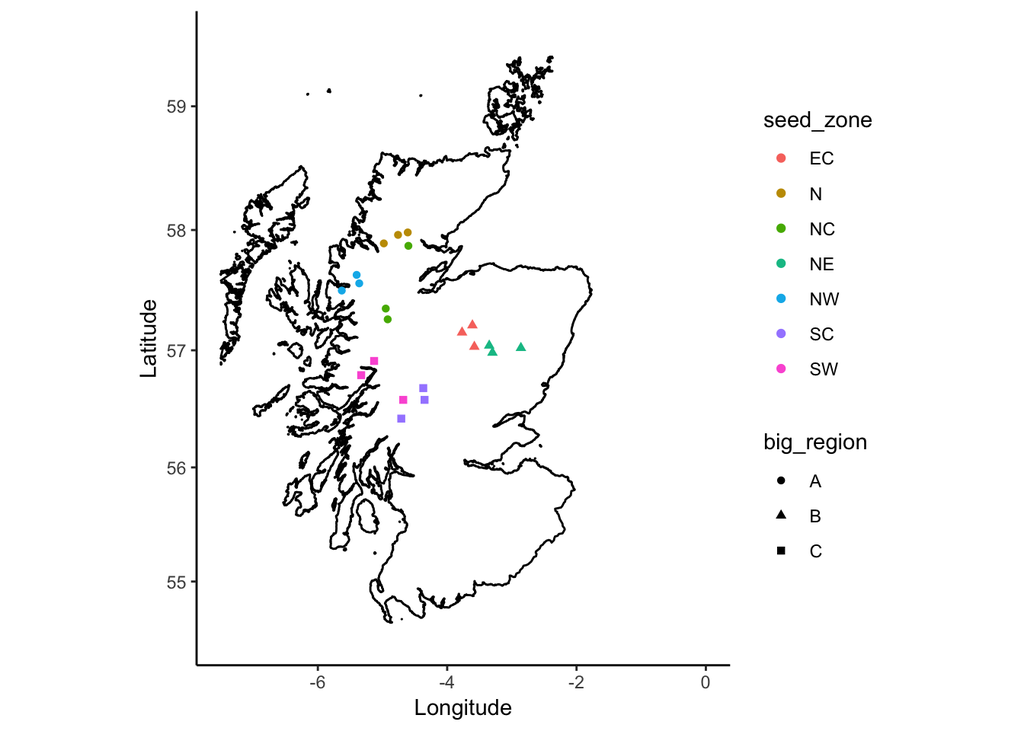

```r
ggplot() +
    geom_polygon(aes(x = long, y = lat, group = group),
                             colour = "black", fill = NA,
                                 data = scotland_fort, alpha = 1) +
    geom_point(aes(x = dec_longitude, y = dec_latitude,
                                 colour = seed_zone, shape = big_region),
                         data = site_loc) +
#   geom_text(aes(x = dec_longitude, y = dec_latitude,
#                                label = name),
#                        size = 1.6,
#                        data = site_loc) +
    theme_classic() +
    theme(legend.position = "right") +
    coord_map() +
    xlim(-7.5, 0) +
    ylim(54.5, 59.5) +
    xlab("Longitude") +
    ylab("Latitude")
```

## Climate space of sites

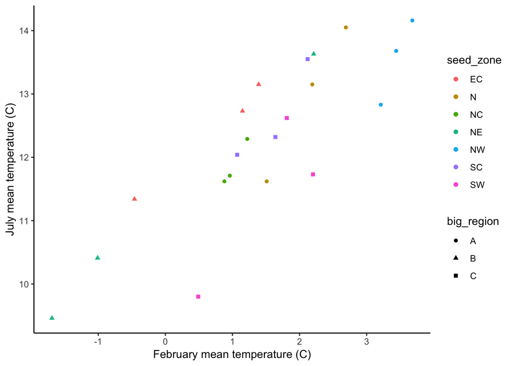

```r
ggplot(site_loc, aes(x = feb_mean_temp_c, y = jul_mean_temp_c)) +
    geom_point(aes(colour = seed_zone, shape = big_region)) +
    labs(x = "February mean temperature (C)",
             y = "July mean temperature (C)") +
    theme_classic()
```

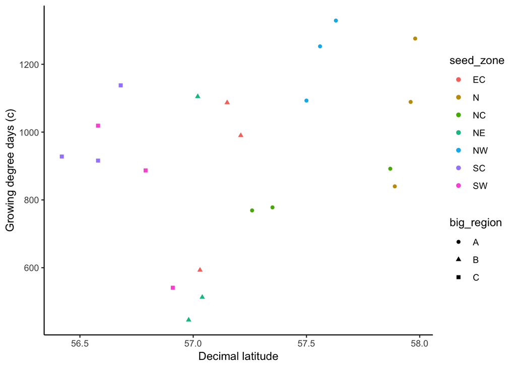

```r
ggplot(site_loc, aes(x = dec_latitude, y = growing_deg_days_c)) +
    geom_point(aes(colour = seed_zone, shape = big_region)) +
    labs(x = "Decimal latitude",
             y = "Growing degree days (c)") +
    theme_classic()
```

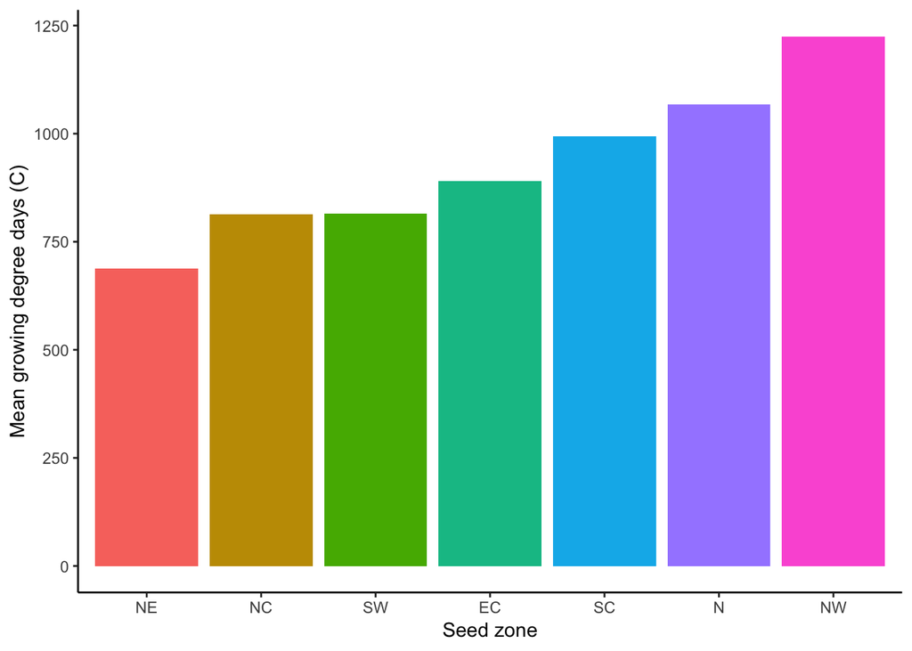

```r
site_loc %>%
    group_by(seed_zone) %>%
    summarise(mean_growing_deg_days_c = mean(growing_deg_days_c)) %>%
    mutate(seed_zone = factor(seed_zone,
                                                        levels = seed_zone[order(.$mean_growing_deg_days_c)])) %>%
    ggplot(aes(x = seed_zone, y = mean_growing_deg_days_c)) +
    geom_bar(stat = "identity", aes(fill = seed_zone)) +
    labs(x = "Seed zone",
             y = "Mean growing degree days (C)") +
    theme_classic() +
    theme(legend.position = "none")
```

## Boxplots of lesions by Scot’s Pine population

Lesions from this year (2015), log+1 transformed, according to regions of seed collection:

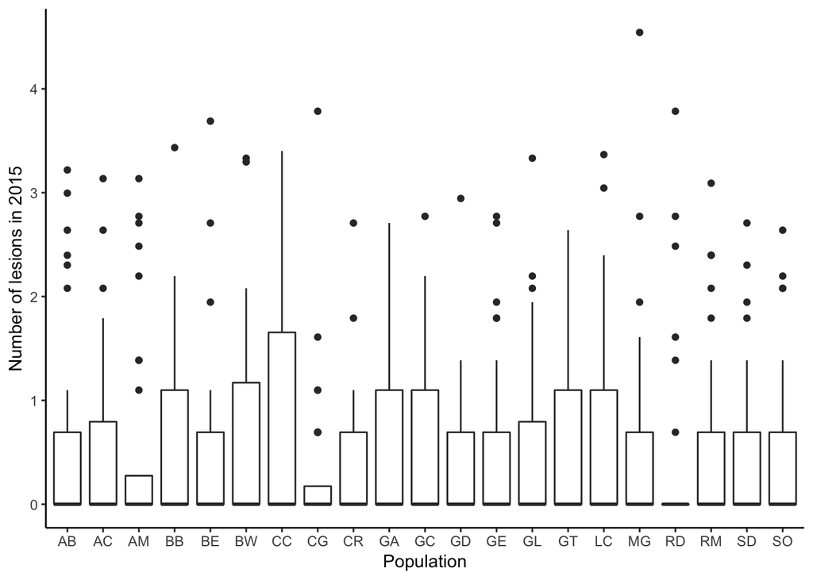

```r
ggplot(damage_full, aes(x = site_code, y = log1p(curr_damage))) +
    geom_boxplot() +
    labs(x = "Population",
             y = "Number of lesions in 2015") +
    theme_classic()
```

Zero inflation makes any patterns hard to see.

Previous lesions only, log+1 transformed:

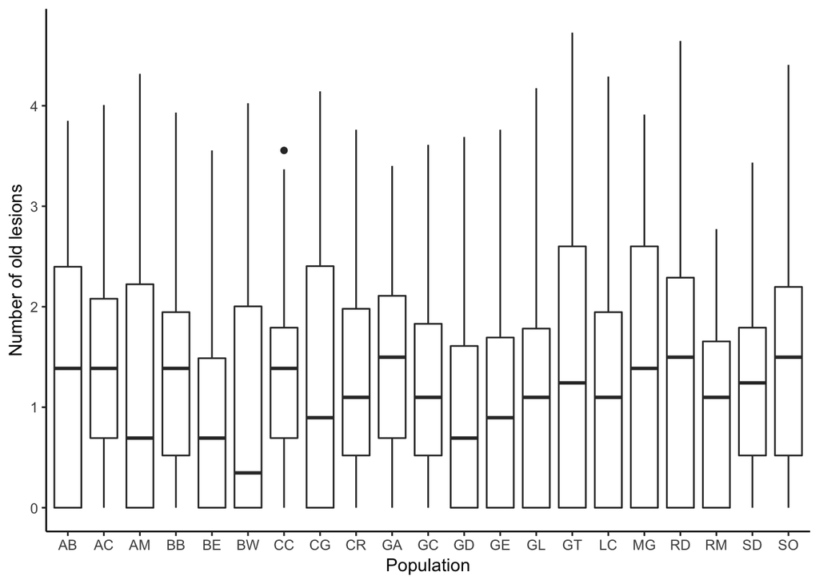

```r
ggplot(damage_full, aes(x = site_code, y = log1p(prev_damage))) +
    geom_boxplot() +
    labs(x = "Population",
             y = "Number of old lesions") +
    theme_classic()
```

All lesions, log+1 transformed:

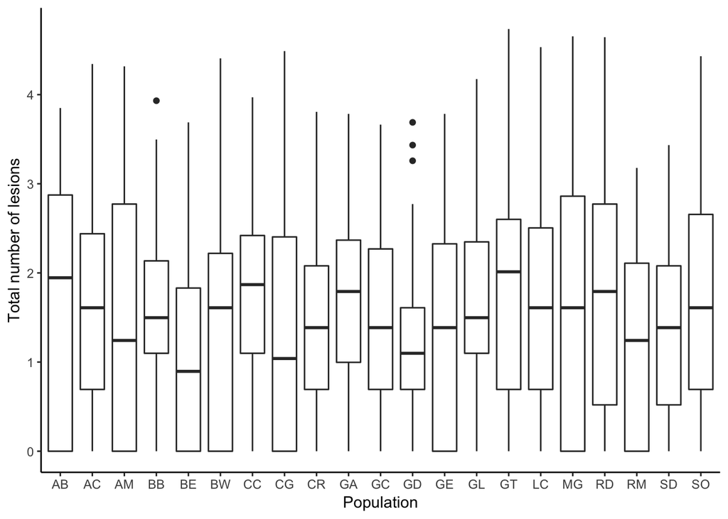

```r
ggplot(damage_full, aes(x = site_code, y = log1p(total_damage))) +
    geom_boxplot() +
    labs(x = "Population",
             y = "Total number of lesions") +
    theme_classic()
```

## Is there a correlation between current damage and previous damage?

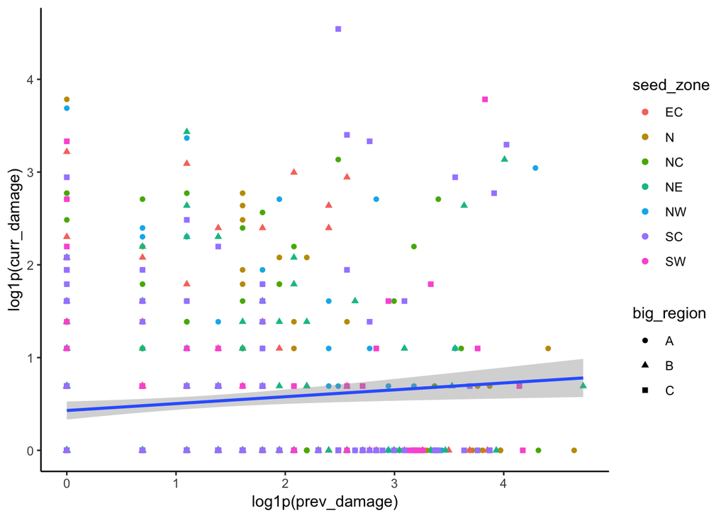

```r
ggplot(damage_full, aes(x = log1p(prev_damage), y = log1p(curr_damage))) +
    geom_point(aes(colour = seed_zone, shape = big_region)) +
    stat_smooth(method = "lm") +
    theme_classic()
```

Not really, not even if we remove all zeroes:

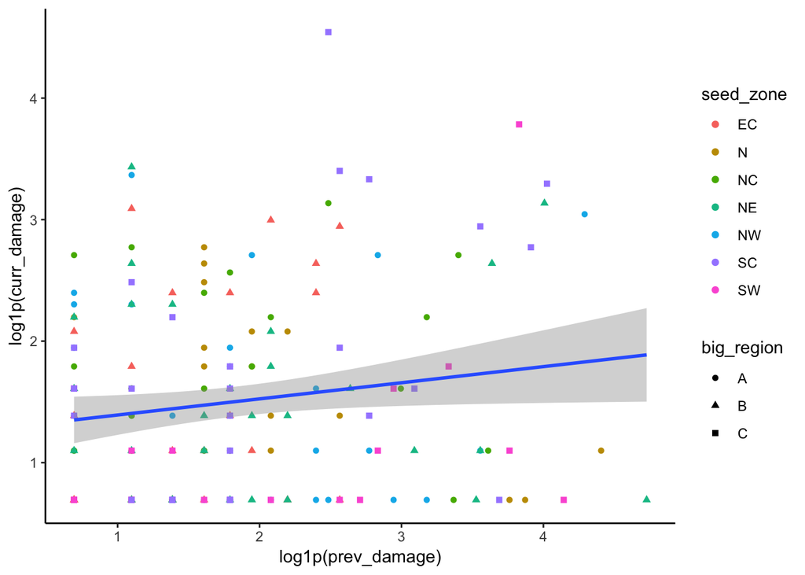

```r
ggplot(filter(damage_full, prev_damage > 0, curr_damage > 0),
    aes(x = log1p(prev_damage), y = log1p(curr_damage))) +
    geom_point(aes(colour = seed_zone, shape = big_region)) +
    stat_smooth(method = "lm") +
    theme_classic()
```

Testing with spearman’s correlations:

```r
cor_dam <- cor.test(damage_full$prev_damage, damage_full$curr_damage, method = "spearman")

damage_nozero_dam <- damage_full %>%
    filter(prev_damage > 0,
                 curr_damage > 0)

cor_dam_nozero <- cor.test(damage_nozero_dam$prev_damage, damage_nozero_dam$curr_damage, method = "spearman")

cor_dam
```

```
##
##  Spearman's rank correlation rho
##
## data:  damage_full$prev_damage and damage_full$curr_damage
## S = 45565000, p-value = 0.01015
## alternative hypothesis: true rho is not equal to 0
## sample estimates:
##        rho
## 0.09910514
```

```r
cor_dam_nozero
```

```
##
##  Spearman's rank correlation rho
##
## data:  damage_nozero_dam$prev_damage and damage_nozero_dam$curr_damage
## S = 808710, p-value = 0.09753
## alternative hypothesis: true rho is not equal to 0
## sample estimates:
##       rho
## 0.1249418
```

There isn’t much of a correlation between current damage and previous damage, even when zeroes are removed. Though the relationship is significant for the correlation including zero, presumably because if a tree wasn’t damaged last year, it wouldn’t be damaged again this year.

Trying with a binomial correlation of damaged or not damaged:

```r
damage_full$prev_damage_binom <- ifelse(damage_full$prev_damage > 0, 1, 0)
damage_full$curr_damage_binom <- ifelse(damage_full$curr_damage > 0, 1, 0)

tetrachoric(table(damage_full$prev_damage_binom,damage_full$curr_damage_binom))
```

```
## Call: tetrachoric(x = table(damage_full$prev_damage_binom, damage_full$curr_damage_binom))
## tetrachoric correlation
## [1] 0.2
##
##  with tau of
##     0     0
## -0.48  0.39
```

Still no real strong positive correlation.

## Exploring spatial patterns in data

Are the populations randomly placed on the grid?

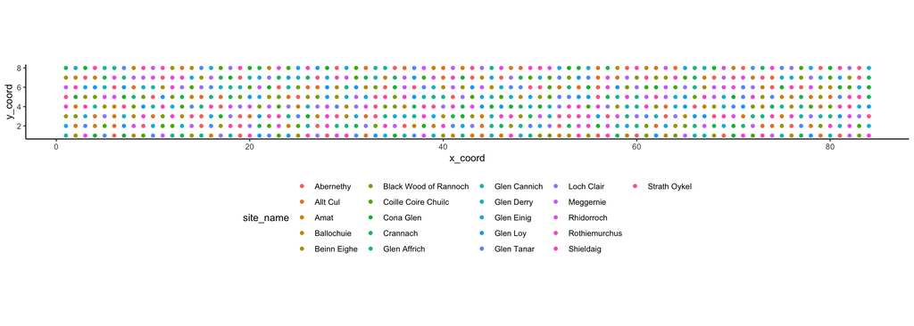

```r
ggplot(damage_full, aes(x = x_coord, y = y_coord)) +
    geom_point(aes(colour = site_name)) +
    coord_equal() +
    theme_classic() +
        theme(legend.position = "bottom")
```

It would seem so.

Spatial autocorrelation in total number of lesions:

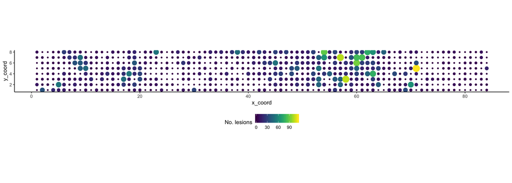

```r
ggplot(damage_full, aes(x = x_coord, y = y_coord)) +
    geom_point(aes(colour = total_damage, size = total_damage)) +
    scale_colour_viridis(name = "No. lesions") +
    scale_size_continuous(guide = FALSE) +
    coord_equal() +
    theme_classic() +
    theme(legend.position = "bottom")
```

Spatial autocorrelation in fresh lesions (this year):

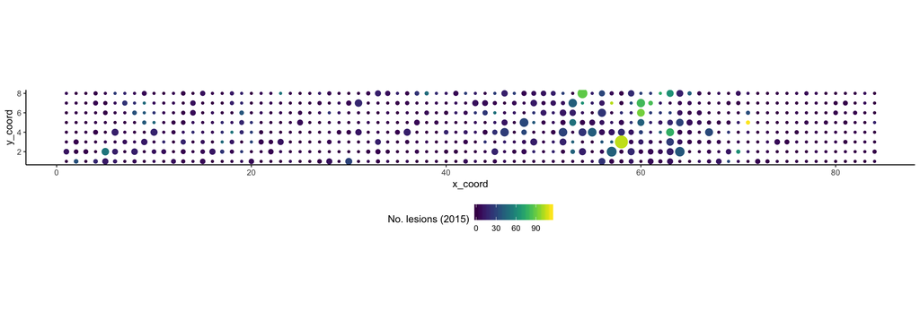

```r
ggplot(damage_full, aes(x = x_coord, y = y_coord)) +
    geom_point(aes(colour = total_damage, size = curr_damage)) +
    scale_colour_viridis(name = "No. lesions (2015)") +
    scale_size_continuous(guide = FALSE) +
    coord_equal() +
    theme_classic() +
    theme(legend.position = "bottom")
```

The weevil damage seems to be clustered in certain areas, possibly the saplings are interacting with each other, with some attracting the weevils and others becoming infected consequentially. The spatial autocorrelation seems to be less pronounced in this year’s lesions than previous years.

# Testing for spatial autocorrelation

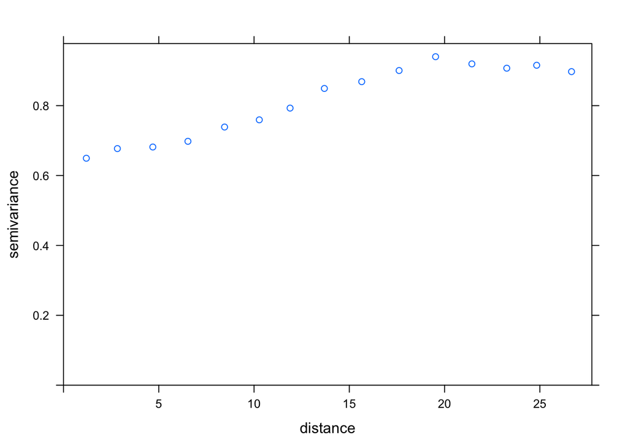

```r
curr_dam_semivar <- variogram(log1p(curr_damage)~1, data = damage_full, locations = ~x_coord+y_coord)

plot(curr_dam_semivar)
```

Spatial autocorrelation is pretty strong across the range of distances, but is this just because there are lots of zero points?

Removing zero points:

```r
damage_no_zero <- damage_full %>%
    filter(curr_damage > 0)
```

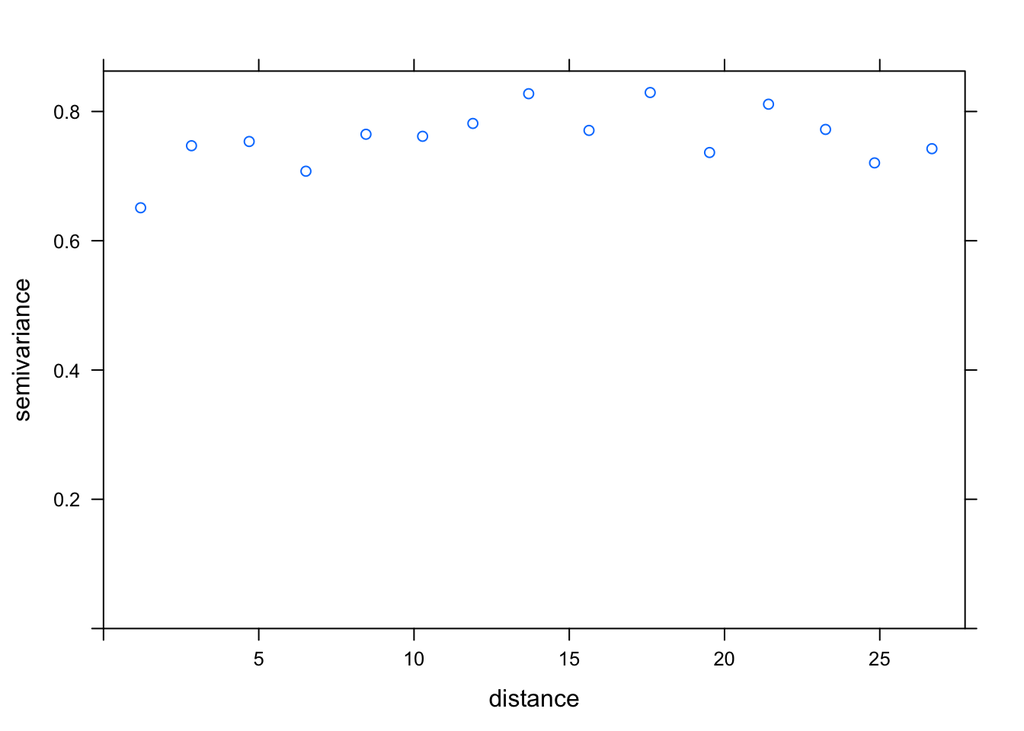

```r
curr_dam_no_zero_semivar <- variogram(log1p(curr_damage)~1, data = damage_no_zero, locations = ~x_coord+y_coord)
plot(curr_dam_no_zero_semivar)
```

# Work spatial structure into a GLM

Basic Generalised Least Squares model and outputs:

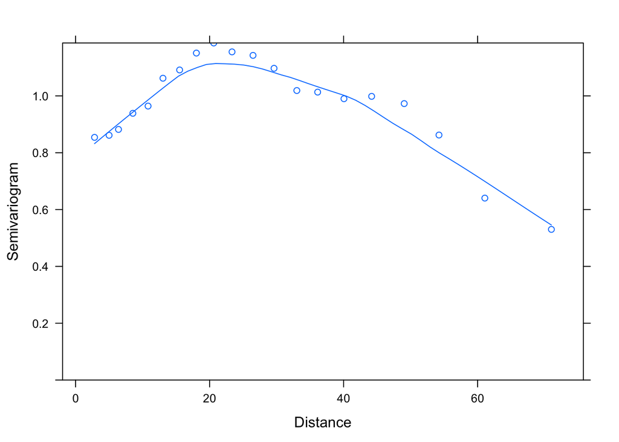

```r
tot_pop_gls <- gls(log1p(curr_damage) ~ site_name , data = damage_full)
vario2 <- Variogram(tot_pop_gls, form = ~x_coord + y_coord, resType = "pearson")

plot(vario2, smooth = TRUE)
```

```r
summary(tot_pop_gls)
```

```
## Generalized least squares fit by REML
##   Model: log1p(curr_damage) ~ site_name
##   Data: damage_full
##        AIC      BIC    logLik
##   1797.356 1895.883 -876.6779
##
## Coefficients:
##                                     Value Std.Error   t-value p-value
## (Intercept)                     0.5878638 0.1555105  3.780219  0.0002
## site_nameAllt Cul              -0.0591716 0.2199251 -0.269053  0.7880
## site_nameAmat                  -0.0513180 0.2199251 -0.233343  0.8156
## site_nameBallochuie             0.0140024 0.2199251  0.063669  0.9493
## site_nameBeinn Eighe           -0.1628533 0.2199251 -0.740495  0.4593
## site_nameBlack Wood of Rannoch  0.0532630 0.2199251  0.242187  0.8087
## site_nameCoille Coire Chuilc    0.2521173 0.2199251  1.146378  0.2521
## site_nameCona Glen             -0.2640063 0.2199251 -1.200437  0.2304
## site_nameCrannach              -0.2269555 0.2199251 -1.031968  0.3025
## site_nameGlen Affrich           0.0127599 0.2199251  0.058020  0.9538
## site_nameGlen Cannich          -0.0703732 0.2199251 -0.319987  0.7491
## site_nameGlen Derry            -0.2105783 0.2199251 -0.957500  0.3387
## site_nameGlen Einig            -0.1228241 0.2199251 -0.558482  0.5767
## site_nameGlen Loy              -0.0027294 0.2199251 -0.012411  0.9901
## site_nameGlen Tanar             0.0153899 0.2199251  0.069978  0.9442
## site_nameLoch Clair             0.1056162 0.2199251  0.480237  0.6312
## site_nameMeggernie             -0.1111995 0.2199251 -0.505624  0.6133
## site_nameRhidorroch            -0.1900336 0.2199251 -0.864084  0.3879
## site_nameRothiemurchus         -0.0561285 0.2199251 -0.255216  0.7986
## site_nameShieldaig             -0.1068608 0.2199251 -0.485897  0.6272
## site_nameStrath Oykel          -0.1641290 0.2199251 -0.746295  0.4558
##
##  Correlation:
##                                (Intr) st_nAC st_nmA st_nmB st_nBE s_BWoR
## site_nameAllt Cul              -0.707
## site_nameAmat                  -0.707  0.500
## site_nameBallochuie            -0.707  0.500  0.500
## site_nameBeinn Eighe           -0.707  0.500  0.500  0.500
## site_nameBlack Wood of Rannoch -0.707  0.500  0.500  0.500  0.500
## site_nameCoille Coire Chuilc   -0.707  0.500  0.500  0.500  0.500  0.500
## site_nameCona Glen             -0.707  0.500  0.500  0.500  0.500  0.500
## site_nameCrannach              -0.707  0.500  0.500  0.500  0.500  0.500
```

[output cut: 67 more lines]

```
## site_nameGlen Loy
## site_nameGlen Tanar
## site_nameLoch Clair
## site_nameMeggernie
## site_nameRhidorroch
## site_nameRothiemurchus
## site_nameShieldaig              0.500
## site_nameStrath Oykel           0.500   0.500
##
## Standardized residuals:
##        Min         Q1        Med         Q3        Max
## -0.9548492 -0.6099189 -0.4816809  0.3590561  4.6227457
##
## Residual standard error: 0.8797002
## Degrees of freedom: 672 total; 651 residual
```

Although this looks like there is negative spatial autocorrelation and large distances, this is probably just an artefact of the data, as I can’t think of any biological reason why there would be a repulsion effect. That’s not how weevils work.

Construct lots of models with different spatial correlation structures, then compare with AIC:

```r
m1 <- gls(log1p(curr_damage) ~ site_name, correlation = corExp(form = ~x_coord +
    y_coord, nugget = TRUE), data = damage_full)

m2 <- gls(log1p(curr_damage) ~ site_name, correlation = corGaus(form = ~x_coord +
    y_coord, nugget = TRUE), data = damage_full)

m2_no_nugget <- gls(log1p(curr_damage) ~ site_name, correlation = corGaus(form = ~x_coord +
    y_coord, nugget = FALSE), data = damage_full)

m3 <- gls(log1p(curr_damage) ~ site_name, correlation = corSpher(form = ~x_coord +
    y_coord, nugget = TRUE), data = damage_full)

m4 <- gls(log1p(curr_damage) ~ site_name, correlation = corLin(form = ~x_coord +
    y_coord, nugget = TRUE), data = damage_full)

m5 <- gls(log1p(curr_damage) ~ site_name, correlation = corRatio(form = ~x_coord +
    y_coord, nugget = TRUE), data = damage_full)

m_null <- gls(log1p(curr_damage) ~ 1, data = damage_full)

aic_table <- data.frame(AIC(m1, m2, m2_no_nugget, m3, m4, m5, tot_pop_gls, m_null)) %>%
    mutate(model_name = rownames(.)) %>%
    dplyr::select(-df) %>%
    arrange(AIC) %>%
    dplyr::select(model_name, AIC)
pander(aic_table)
```

| model_name | AIC |
| --- | --- |
| m2 | 1710 |
| m5 | 1711 |
| m1 | 1714 |
| m_null | 1735 |
| m2_no_nugget | 1772 |
| m3 | 1778 |
| m4 | 1778 |
| tot_pop_gls | 1797 |

`m2` is the best model according to AIC. There is definitely an effect of spatial autocorrelation as the AIC of `m_no_cor` is the highest of all the models and is higher than a null model.

Exploring the best fitted model (`m2`). First look at a semivariogram of the normalised residuals and the fit of the correlation structure on the raw values:

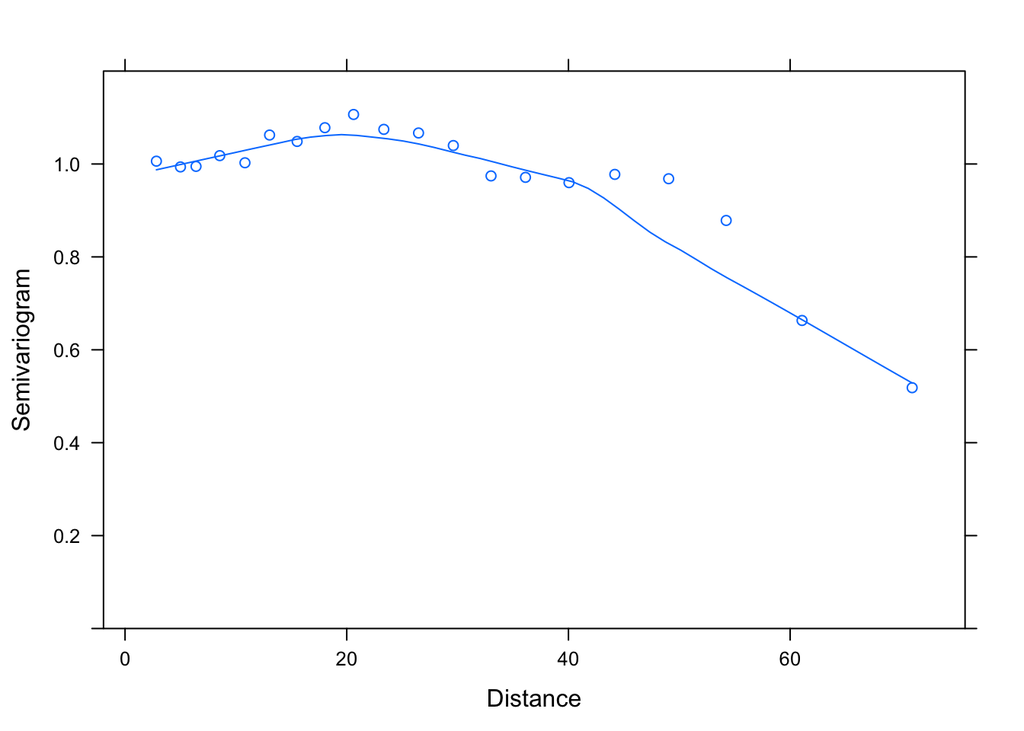

```r
vario2_resid <- Variogram(m2, form = ~x_coord + y_coord, resType = "normalized")
vario2_fit <- Variogram(m2, form = ~x_coord + y_coord, resType = "pearson")
plot(vario2_resid, smooth = TRUE, ylim = c(0, 1.2))
```

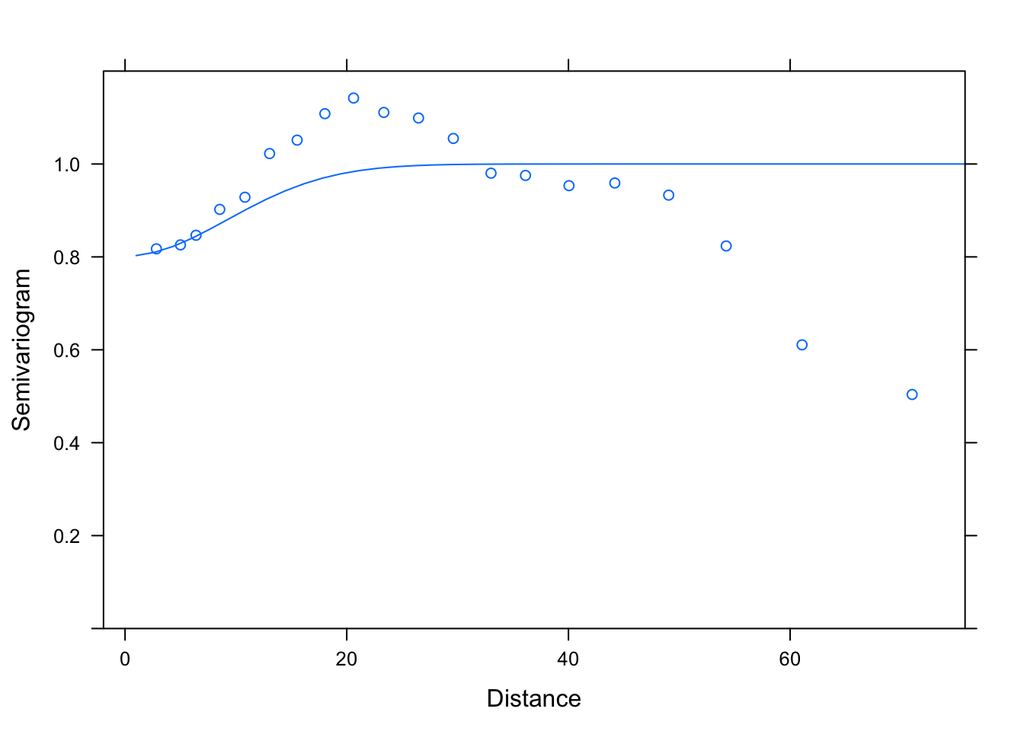

```r
plot(vario2_fit, ylim = c(0, 1.2))
```

The fit of the correlation structure isn’t great (blue line), I still don’t understand the semivariogram which decreases at higher distances, but that might not be a massive issue.

Next, look at the standardized residuals of the model:

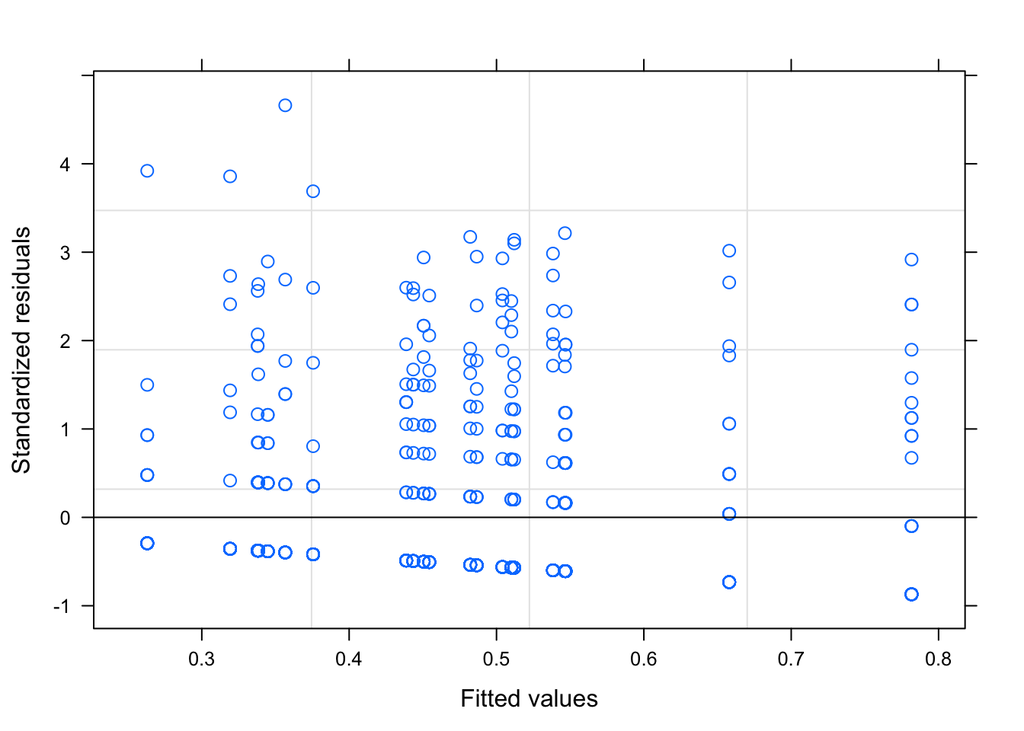

```r
plot(m2, which = 1:4)
```

Standardized residuals don’t show any pattern with the fitted values, so that model assumption isn’t violated.

And next the normality of residuals:

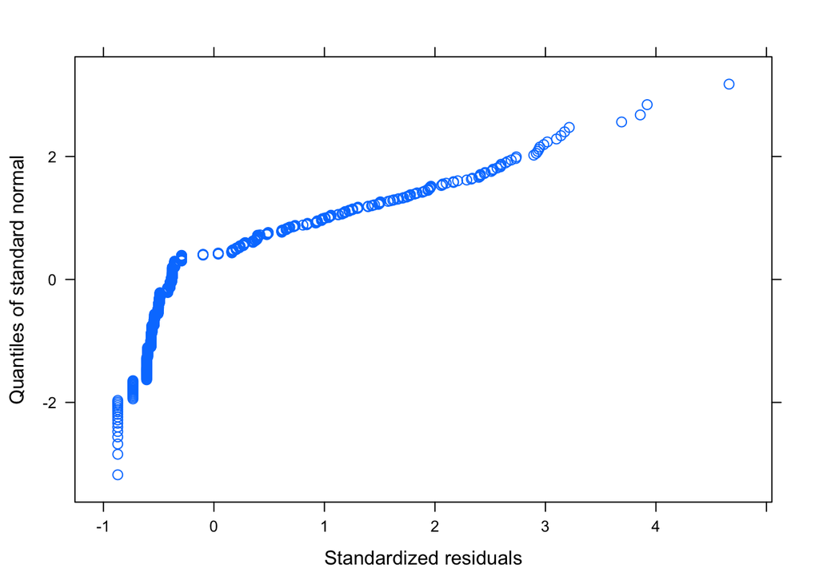

```r
qqnorm(m2)
```

This is dodgy because the data comes from a zero inflated count distribution, even if it has been log transformed since.

Finally, look at the model outputs:

```r
summary(m2)
```

```
## Generalized least squares fit by REML
##   Model: log1p(curr_damage) ~ site_name
##   Data: damage_full
##        AIC      BIC    logLik
##   1709.573 1817.057 -830.7865
##
## Correlation Structure: Gaussian spatial correlation
##  Formula: ~x_coord + y_coord
##  Parameter estimate(s):
##      range     nugget
## 13.0123497  0.8017255
##
## Coefficients:
##                                     Value Std.Error    t-value p-value
## (Intercept)                     0.5383225 0.2333109  2.3073181  0.0213
## site_nameAllt Cul              -0.0517610 0.2019440 -0.2563136  0.7978
## site_nameAmat                  -0.0342995 0.2030845 -0.1688926  0.8659
## site_nameBallochuie             0.0081113 0.2021927  0.0401165  0.9680
## site_nameBeinn Eighe           -0.1627773 0.2023416 -0.8044675  0.4214
## site_nameBlack Wood of Rannoch -0.0263074 0.2023837 -0.1299878  0.8966
## site_nameCoille Coire Chuilc    0.2433496 0.2018345  1.2056888  0.2284
## site_nameCona Glen             -0.2753499 0.2024172 -1.3603084  0.1742
## site_nameCrannach              -0.1999951 0.2019577 -0.9902822  0.3224
## site_nameGlen Affrich          -0.0282355 0.2021435 -0.1396803  0.8890
## site_nameGlen Cannich          -0.0995899 0.2020468 -0.4929052  0.6222
## site_nameGlen Derry            -0.1935394 0.2030463 -0.9531784  0.3409
## site_nameGlen Einig            -0.0948144 0.2025547 -0.4680929  0.6399
## site_nameGlen Loy              -0.0561507 0.2020239 -0.2779409  0.7811
## site_nameGlen Tanar             0.0085607 0.2021055  0.0423576  0.9662
## site_nameLoch Clair             0.1196209 0.2017184  0.5930094  0.5534
## site_nameMeggernie             -0.1816885 0.2028012 -0.8958944  0.3706
## site_nameRhidorroch            -0.2191087 0.2020970 -1.0841762  0.2787
## site_nameRothiemurchus         -0.0877616 0.2023606 -0.4336892  0.6647
## site_nameShieldaig             -0.0839582 0.2024576 -0.4146951  0.6785
## site_nameStrath Oykel          -0.2003973 0.2027189 -0.9885479  0.3233
##
##  Correlation:
##                                (Intr) st_nAC st_nmA st_nmB st_nBE s_BWoR
## site_nameAllt Cul              -0.430
## site_nameAmat                  -0.434  0.499
```

[output cut: 73 more lines]

```
## site_nameGlen Loy
## site_nameGlen Tanar
## site_nameLoch Clair
## site_nameMeggernie
## site_nameRhidorroch
## site_nameRothiemurchus
## site_nameShieldaig              0.498
## site_nameStrath Oykel           0.502   0.503
##
## Standardized residuals:
##        Min         Q1        Med         Q3        Max
## -0.8703802 -0.5417790 -0.3839108  0.3896953  4.6617845
##
## Residual standard error: 0.8980812
## Degrees of freedom: 672 total; 651 residual
```

```r
anova(m2)
```

```
## Denom. DF: 651
##             numDF  F-value p-value
## (Intercept)     1 5.889275  0.0155
## site_name      20 0.709936  0.8182
```

```r
r.squaredLR(m2, null = m_null)
```

```
## [1] 0.1438731
## attr(,"adj.r.squared")
## [1] 0.1558144
```

```r
r.squaredLR(m2)
```

```
## [1] 0.1438731
## attr(,"adj.r.squared")
## [1] 0.1558144
```

# Adding family level predictors to the model

```r
m2_fam_nest <- gls(log1p(curr_damage) ~ family:site_name, correlation = corGaus(form = ~x_coord +
    y_coord, nugget = TRUE), data = damage_full)
```

```
## Error in glsEstimate(object, control = control): computed "gls" fit is singular, rank 169
```

```r
m2_fam <- gls(log1p(curr_damage) ~ family,
                            correlation = corGaus(form = ~x_coord + y_coord, nugget = TRUE),
                            data = damage_full)

m1_fam <- gls(log1p(curr_damage) ~ family,
                            correlation = corExp(form = ~x_coord + y_coord, nugget = TRUE),
                            data = damage_full)

m3_fam <- gls(log1p(curr_damage) ~ family,
                            correlation = corSpher(form = ~x_coord + y_coord, nugget = TRUE),
                            data = damage_full)

m4_fam <- gls(log1p(curr_damage) ~ family,
                            correlation = corLin(form = ~x_coord + y_coord, nugget = TRUE),
                            data = damage_full)

m5_fam <- gls(log1p(curr_damage) ~ family,
                            correlation = corRatio(form = ~x_coord + y_coord, nugget = TRUE),
                            data = damage_full)
```

```r
aic_table <- data.frame(AIC(m1, m2, m2_no_nugget, m3, m4, m5, tot_pop_gls, m_null, m1_fam, m2_fam, m3_fam, m4_fam, m5_fam)) %>%
    mutate(model_name = rownames(.)) %>%
    dplyr::select(-df) %>%
    arrange(AIC) %>%
    dplyr::select(model_name, AIC)
pander(aic_table)
```

| model_name | AIC |
| --- | --- |
| m2 | 1710 |
| m5 | 1711 |
| m1 | 1714 |
| m_null | 1735 |
| m2_no_nugget | 1772 |
| m3 | 1778 |
| m4 | 1778 |
| tot_pop_gls | 1797 |
| m2_fam | 1819 |
| m5_fam | 1820 |
| m1_fam | 1824 |
| m4_fam | 1881 |
| m3_fam | 1881 |

Currently, the GLS with family nested within population doesn’t converge due to singularities, I think this is because by nesting, they actually mean “crossed effects”. If I just include family level effects and compare to the previous population level models, I STILL don’t get any better than the population level Gaussian correlation structure model (`m2`).

```r
Anova(m2, type = "II")
```

```
## Analysis of Deviance Table (Type II tests)
##
## Response: log1p(curr_damage)
##           Df  Chisq Pr(>Chisq)
## site_name 20 14.199     0.8203
```

```r
Anova(m2_fam, type = "II")
```

```
## Analysis of Deviance Table (Type II tests)
##
## Response: log1p(curr_damage)
##         Df  Chisq Pr(>Chisq)
## family 167 147.35     0.8608
```

# Linear mixed effects models - no correlation structure, family level

```r
curr_fam_lmer <- lmer(log1p(curr_damage) ~ family + (1|site_name), data = damage_full)
curr_pop_lmer <- lmer(log1p(curr_damage) ~ site_name + (1|block), data = damage_full)
curr_lmer_rand <- lmer(log1p(curr_damage) ~ (1|site_name), data = damage_full)
curr_lmer_null <- lm(log1p(curr_damage) ~ 1, data = damage_full)
```

```r
summary(curr_fam_lmer)
```

```
## Linear mixed model fit by REML ['lmerMod']
## Formula: log1p(curr_damage) ~ family + (1 | site_name)
##    Data: damage_full
##
## REML criterion at convergence: 1552.9
##
## Scaled residuals:
##     Min      1Q  Median      3Q     Max
## -1.8830 -0.5800 -0.1933  0.3867  3.8016
##
## Random effects:
##  Groups    Name        Variance Std.Dev.
##  site_name (Intercept) 0.01532  0.1238
##  Residual              0.80340  0.8963
## Number of obs: 672, groups:  site_name, 21
##
## Fixed effects:
##               Estimate Std. Error t value
## (Intercept)  5.199e-01  4.649e-01   1.118
## familyAB10   3.132e-01  6.338e-01   0.494
## familyAB2    4.024e-01  6.338e-01   0.635
## familyAB3    3.543e-01  6.338e-01   0.559
## familyAB4    2.849e-01  6.338e-01   0.449
## familyAB5   -5.199e-01  6.338e-01  -0.820
## familyAB6    5.579e-02  6.338e-01   0.088
## familyAB9   -3.466e-01  6.338e-01  -0.547
## familyAC1   -2.452e-01  6.575e-01  -0.373
## familyAC2   -3.466e-01  6.575e-01  -0.527
## familyAC3    3.303e-14  6.575e-01   0.000
## familyAC5    1.014e-01  6.575e-01   0.154
## familyAC6   -1.733e-01  6.575e-01  -0.264
## familyAC7    5.878e-01  6.575e-01   0.894
## familyAC8   -1.175e-01  6.575e-01  -0.179
## familyAC9    2.640e-01  6.575e-01   0.402
## familyAM1    1.572e-01  6.575e-01   0.239
## familyAM10   5.199e-01  6.575e-01   0.791
## familyAM3   -5.199e-01  6.575e-01  -0.791
## familyAM4    1.088e+00  6.575e-01   1.655
## familyAM5   -5.199e-01  6.575e-01  -0.791
## familyAM6    1.014e-01  6.575e-01   0.154
```

[output cut: 131 more lines]

```
## familySD10   5.579e-02  6.575e-01   0.085
## familySD2    1.733e-01  6.575e-01   0.264
## familySD4   -5.199e-01  6.575e-01  -0.791
## familySD6   -5.199e-01  6.575e-01  -0.791
## familySD7    3.760e-01  6.575e-01   0.572
## familySD8   -5.199e-01  6.575e-01  -0.791
## familySD9    4.865e-01  6.575e-01   0.740
## familySO10  -5.199e-01  6.575e-01  -0.791
## familySO2   -5.199e-01  6.575e-01  -0.791
## familySO3   -3.466e-01  6.575e-01  -0.527
## familySO4    1.733e-01  6.575e-01   0.264
## familySO5    1.399e-01  6.575e-01   0.213
## familySO6    4.774e-01  6.575e-01   0.726
## familySO7    3.466e-01  6.575e-01   0.527
## familySO9   -5.199e-01  6.575e-01  -0.791
```

```
##
## Correlation matrix not shown by default, as p = 168 > 12.
## Use print(x, correlation=TRUE)  or
##   vcov(x)     if you need it
```

```
## convergence code: 0
## unable to evaluate scaled gradient
##  Hessian is numerically singular: parameters are not uniquely determined
```

```r
aic_table_lmer <- data.frame(AIC(curr_fam_lmer, curr_lmer_rand, curr_lmer_null, curr_pop_lmer)) %>%
    mutate(model_name = rownames(.)) %>%
    dplyr::select(-df) %>%
    arrange(AIC) %>%
    dplyr::select(model_name, AIC)
pander(aic_table_lmer)
```

| model_name | AIC |
| --- | --- |
| curr_lmer_null | 1730 |
| curr_lmer_rand | 1737 |
| curr_pop_lmer | 1745 |
| curr_fam_lmer | 1893 |

The null model is better than any family level mixed effects model, and is better than a mixed model including population. This null result is likely because I am unable to include the spatial autocorrelation structure in the linear model, and this takes up a lot of the variance.

# Using larger population groupings and climate variables

Family level groupings didn’t appear to predict weevil damage at all and population (site) level groupings don’t predict very much either, so what if I group into larger groups such as `seed_zone` and `big_region`?

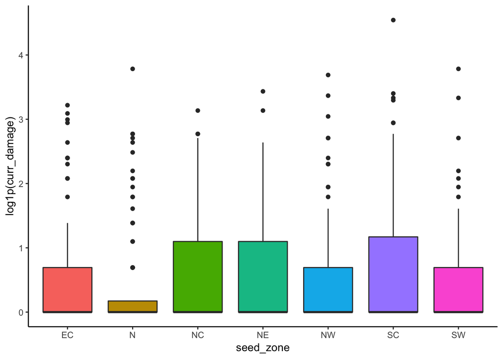

```r
ggplot(damage_full, aes(x = seed_zone, y = log1p(curr_damage))) +
    geom_boxplot(aes(fill = seed_zone)) +
    theme_classic() +
    theme(legend.position = "none")
```

The following model uses the same auto-correlation structure as the previous models, but uses seed zone rather than family as the categorical predictor.

```r
m2_sz <- gls(curr_damage ~ seed_zone,
                            correlation = corGaus(form = ~x_coord + y_coord, nugget = TRUE),
                            data = damage_full)
summary(m2_sz)
```

```
## Generalized least squares fit by REML
##   Model: curr_damage ~ seed_zone
##   Data: damage_full
##        AIC      BIC    logLik
##   4302.714 4347.712 -2141.357
##
## Correlation Structure: Gaussian spatial correlation
##  Formula: ~x_coord + y_coord
##  Parameter estimate(s):
##      range     nugget
## 12.2664550  0.8793768
##
## Coefficients:
##                  Value Std.Error    t-value p-value
## (Intercept)  1.6481584 1.1450844  1.4393336  0.1505
## seed_zoneN  -0.2320922 0.8466448 -0.2741317  0.7841
## seed_zoneNC -0.0275360 0.8435759 -0.0326420  0.9740
## seed_zoneNE  0.0067640 0.8433457  0.0080204  0.9936
## seed_zoneNW  0.1768036 0.8460896  0.2089656  0.8345
## seed_zoneSC  1.2492957 0.8460666  1.4765926  0.1403
## seed_zoneSW -0.4335683 0.8440933 -0.5136497  0.6077
##
##  Correlation:
##             (Intr) sd_znN sd_zNC sd_zNE sd_zNW sd_zSC
## seed_zoneN  -0.373
## seed_zoneNC -0.365  0.495
## seed_zoneNE -0.366  0.498  0.500
## seed_zoneNW -0.371  0.501  0.497  0.496
## seed_zoneSC -0.364  0.499  0.497  0.499  0.496
## seed_zoneSW -0.372  0.502  0.498  0.498  0.501  0.500
##
## Standardized residuals:
##         Min          Q1         Med          Q3         Max
## -0.46653804 -0.26646987 -0.22801008 -0.05888329 14.50800050
##
## Residual standard error: 6.210542
## Degrees of freedom: 672 total; 665 residual
```

```r
Anova(m2_sz)
```

```
## Analysis of Deviance Table (Type II tests)
##
## Response: curr_damage
##           Df  Chisq Pr(>Chisq)
## seed_zone  6 4.8999     0.5567
```

This model uses big_region as the categorical predictor:

```r
m2_br <- gls(curr_damage ~ big_region,
                            correlation = corGaus(form = ~x_coord + y_coord, nugget = TRUE),
                            data = damage_full)
summary(m2_br)
```

```
## Generalized least squares fit by REML
##   Model: curr_damage ~ big_region
##   Data: damage_full
##        AIC     BIC    logLik
##   4304.635 4331.67 -2146.318
##
## Correlation Structure: Gaussian spatial correlation
##  Formula: ~x_coord + y_coord
##  Parameter estimate(s):
##      range     nugget
## 12.2403745  0.8774382
##
## Coefficients:
##                 Value Std.Error  t-value p-value
## (Intercept) 1.6029194 1.0417223 1.538720  0.1243
## big_regionB 0.0272063 0.5460247 0.049826  0.9603
## big_regionC 0.4289262 0.5458577 0.785784  0.4323
##
##  Correlation:
##             (Intr) bg_rgB
## big_regionB -0.205
## big_regionC -0.206  0.400
##
## Standardized residuals:
##         Min          Q1         Med          Q3         Max
## -0.32680600 -0.26219257 -0.25781667 -0.09697472 14.63149454
##
## Residual standard error: 6.217284
## Degrees of freedom: 672 total; 669 residual
```

```r
Anova(m2_br, type = "II")
```

```
## Analysis of Deviance Table (Type II tests)
##
## Response: curr_damage
##            Df  Chisq Pr(>Chisq)
## big_region  2 0.7005     0.7045
```

```r
aic_table <- data.frame(AIC(m1, m2, m2_no_nugget, m3, m4, m5, tot_pop_gls, m_null, m1_fam, m2_fam, m3_fam, m4_fam, m5_fam, m2_sz, m2_br)) %>%
    mutate(model_name = rownames(.)) %>%
    dplyr::select(-df) %>%
    arrange(AIC) %>%
    dplyr::select(model_name, AIC)
pander(aic_table)
```

| model_name | AIC |
| --- | --- |
| m2 | 1710 |
| m5 | 1711 |
| m1 | 1714 |
| m_null | 1735 |
| m2_no_nugget | 1772 |
| m3 | 1778 |
| m4 | 1778 |
| tot_pop_gls | 1797 |
| m2_fam | 1819 |
| m5_fam | 1820 |
| m1_fam | 1824 |
| m4_fam | 1881 |
| m3_fam | 1881 |
| m2_sz | 4303 |
| m2_br | 4305 |

Seed zone accounts for more variance than big_region, but both models are vastly worse at predicting weevil damage than population level models.